# (San Francisco Bay Area Bike-Sharing System Exploration )

## Preliminary Wrangling

> This data set includes information about individual rides made in a bike-sharing system covering the greater San Francisco Bay area

```python
# import all packages and set plots to be embedded inline
import numpy as np
import pandas as pd
import matplotlib.pyplot as plt
import seaborn as sb

%matplotlib inline
```

> Load in your dataset and describe its properties through the questions below. Try and motivate your exploration goals through this section.

```python
bike = pd.read_csv('fordgobike.csv')
bike.head()
```

|  | duration_sec | start_time | end_time | start_station_id | start_station_name | start_station_latitude | start_station_longitude | end_station_id | end_station_name | end_station_latitude | end_station_longitude | bike_id | user_type | member_birth_year | member_gender | bike_share_for_all_trip |
| --- | --- | --- | --- | --- | --- | --- | --- | --- | --- | --- | --- | --- | --- | --- | --- | --- |
| 0 | 52185 | 2019-02-28 17:32:10.1450 | 2019-03-01 08:01:55.9750 | 21.0 | Montgomery St BART Station (Market St at 2nd St) | 37.789625 | -122.400811 | 13.0 | Commercial St at Montgomery St | 37.794231 | -122.402923 | 4902 | Customer | 1984.0 | Male | No |
| 1 | 42521 | 2019-02-28 18:53:21.7890 | 2019-03-01 06:42:03.0560 | 23.0 | The Embarcadero at Steuart St | 37.791464 | -122.391034 | 81.0 | Berry St at 4th St | 37.775880 | -122.393170 | 2535 | Customer | NaN | NaN | No |
| 2 | 61854 | 2019-02-28 12:13:13.2180 | 2019-03-01 05:24:08.1460 | 86.0 | Market St at Dolores St | 37.769305 | -122.426826 | 3.0 | Powell St BART Station (Market St at 4th St) | 37.786375 | -122.404904 | 5905 | Customer | 1972.0 | Male | No |
| 3 | 36490 | 2019-02-28 17:54:26.0100 | 2019-03-01 04:02:36.8420 | 375.0 | Grove St at Masonic Ave | 37.774836 | -122.446546 | 70.0 | Central Ave at Fell St | 37.773311 | -122.444293 | 6638 | Subscriber | 1989.0 | Other | No |
| 4 | 1585 | 2019-02-28 23:54:18.5490 | 2019-03-01 00:20:44.0740 | 7.0 | Frank H Ogawa Plaza | 37.804562 | -122.271738 | 222.0 | 10th Ave at E 15th St | 37.792714 | -122.248780 | 4898 | Subscriber | 1974.0 | Male | Yes |

```python
bike.info()
```

```
<class 'pandas.core.frame.DataFrame'>
RangeIndex: 183412 entries, 0 to 183411
Data columns (total 16 columns):
 #   Column                   Non-Null Count   Dtype
---  ------                   --------------   -----
 0   duration_sec             183412 non-null  int64
 1   start_time               183412 non-null  object
 2   end_time                 183412 non-null  object
 3   start_station_id         183215 non-null  float64
 4   start_station_name       183215 non-null  object
 5   start_station_latitude   183412 non-null  float64
 6   start_station_longitude  183412 non-null  float64
 7   end_station_id           183215 non-null  float64
 8   end_station_name         183215 non-null  object
 9   end_station_latitude     183412 non-null  float64
 10  end_station_longitude    183412 non-null  float64
 11  bike_id                  183412 non-null  int64
 12  user_type                183412 non-null  object
 13  member_birth_year        175147 non-null  float64
 14  member_gender            175147 non-null  object
 15  bike_share_for_all_trip  183412 non-null  object
dtypes: float64(7), int64(2), object(7)
memory usage: 22.4+ MB
```

```python
#check nulls at member_birth_year column
bike.member_birth_year.isnull().sum()
```

```
8265
```

```python
#check nulls at start_station_id column
bike.start_station_id.isnull().sum()
```

```
197
```

```python
#Check duplicates
bike.duplicated().sum()
```

```
0
```

```python
#Satrt cleaning data - make a copy of original data
bike_df = bike.copy()
```

```python
#Drop null rows at member_birth_year
bike_df.drop(bike_df[bike_df.member_birth_year.isnull()].index, inplace= True)
```

```python
#test null rows at member_birth_year
bike_df.member_birth_year.isnull().sum()
```

```
0
```

```python
#Drop null rows at start_station_id
bike_df.drop(bike_df[bike_df.start_station_id.isnull()].index, inplace= True)
```

```python
#test null rows at start_station_id
bike_df.start_station_id.isnull().sum()
```

```
0
```

```python
(bike_df.start_station_id == bike_df.end_station_id).sum()
```

```
3458
```

```python
bike_df.start_time = pd.to_datetime(bike_df.start_time)
bike_df.end_time = pd.to_datetime(bike_df.end_time)
```

```python
bike_df['day'] = bike_df['start_time'].apply(lambda time: time.dayofweek)
day = {0:'Mon',1:'Tue',2:'Wed',3:'Thu',4:'Fri',5:'Sat',6:'Sun'}
bike_df['day'] = bike_df['day'].map(day)
```

```python
bike_df['day_num'] = bike_df['start_time'].apply(lambda time: time.dayofweek)
```

```python
bike_df['hour'] = bike_df['start_time'].apply(lambda time: time.hour)
```

```python
# order the day weeks
days = ['Mon', 'Tue', 'Wed', 'Thu', 'Fri', 'Sat', 'Sun']
week_days = pd.api.types.CategoricalDtype(ordered = True, categories= days)
bike_df['day']=bike_df['day'].astype(week_days)
```

```python
bike_df.info()
```

```
<class 'pandas.core.frame.DataFrame'>
Int64Index: 174952 entries, 0 to 183411
Data columns (total 19 columns):
 #   Column                   Non-Null Count   Dtype
---  ------                   --------------   -----
 0   duration_sec             174952 non-null  int64
 1   start_time               174952 non-null  datetime64[ns]
 2   end_time                 174952 non-null  datetime64[ns]
 3   start_station_id         174952 non-null  float64
 4   start_station_name       174952 non-null  object
 5   start_station_latitude   174952 non-null  float64
 6   start_station_longitude  174952 non-null  float64
 7   end_station_id           174952 non-null  float64
 8   end_station_name         174952 non-null  object
 9   end_station_latitude     174952 non-null  float64
 10  end_station_longitude    174952 non-null  float64
 11  bike_id                  174952 non-null  int64
 12  user_type                174952 non-null  object
 13  member_birth_year        174952 non-null  float64
 14  member_gender            174952 non-null  object
 15  bike_share_for_all_trip  174952 non-null  object
 16  day                      174952 non-null  category
 17  day_num                  174952 non-null  int64
 18  hour                     174952 non-null  int64
dtypes: category(1), datetime64[ns](2), float64(7), int64(4), object(5)
memory usage: 25.5+ MB
```

### What is the structure of your dataset?

> We have 174952 row data set for Bike-Share aystem at San Francisco pay area has data about noumber seconds of bike using, the start and end time of using bike, the start station and end station of using bike, aslo information about users (birth year, gender, Subscriber or not)

### What is/are the main feature(s) of interest in your dataset?

> I'm interested in figuring out the distribution of time spent using bike 24/7 and which age group prefer bike share

### What features in the dataset do you think will help support your investigation into your feature(s) of interest?

> Duration in seconds and End Time will be the main feature as it the way we use to measure the time spent and its pattern

## Univariate Exploration

> In this section, investigate distributions of individual variables. If you see unusual points or outliers, take a deeper look to clean things up and prepare yourself to look at relationships between variables.

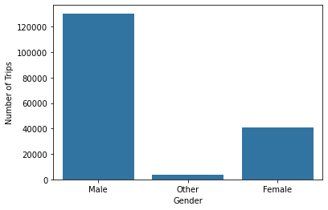

```python
#check the gender distribution
color_base = sb.color_palette()[0]
sb.countplot(data = bike_df, x= 'member_gender', color = color_base)
plt.ylabel('Number of Trips')
plt.xlabel('Gender');
```

> Make sure that, after every plot or related series of plots, that you include a Markdown cell with comments about what you observed, and what you plan on investigating next.

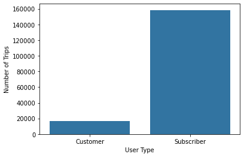

```python
#check the gender distribution
sb.countplot(data = bike_df, x= 'user_type', color = color_base)
plt.ylabel('Number of Trips')
plt.xlabel('User Type');
```

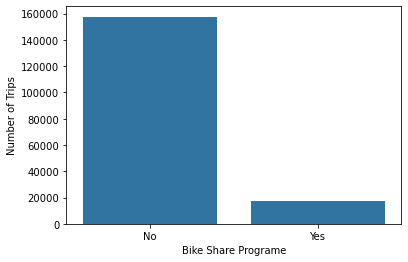

```python
#check the bike_share distribution
sb.countplot(data= bike_df, x='bike_share_for_all_trip', color = color_base);
plt.ylabel('Number of Trips')
plt.xlabel('Bike Share Programe');
```

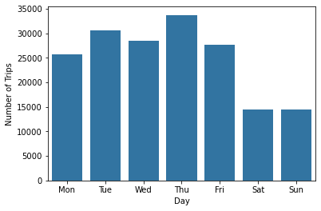

```python
#check the bike_share distribution
sb.countplot(data= bike_df, x='day', color = color_base)

plt.ylabel('Number of Trips')
plt.xlabel('Day');
```

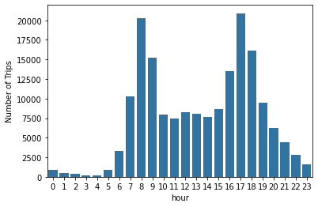

```python
#check the bike using at per start time hour
sb.countplot(data= bike_df, x='hour', color = color_base);
plt.ylabel('Number of Trips')
plt.xlabel('hour');
```

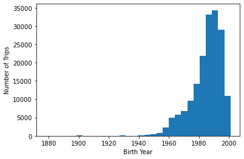

```python
#check the member birth distribution
plt.hist(data = bike_df, x='member_birth_year', bins = 30);
plt.ylabel('Number of Trips')
plt.xlabel('Birth Year');
#plt.xlim(1940, 2002)
```

```python
#drop trips for members with bitrh year below 1939
bike_df.drop(bike_df[bike_df.member_birth_year < 1939].index, inplace= True)
```

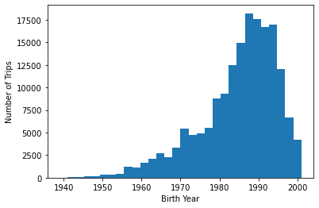

```python
#check the member birth distribution after applying dropping
plt.hist(data = bike_df, x='member_birth_year', bins = 30);
plt.ylabel('Number of Trips')
plt.xlabel('Birth Year');
#plt.xlim(1940, 2002);
```

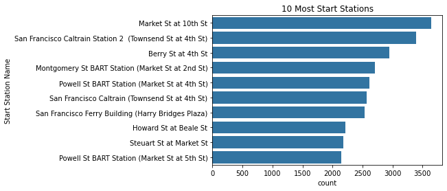

```python
#Check most start stations
sb.countplot(data = bike_df, y = 'start_station_name', order =bike_df.start_station_name.value_counts().index[:10] , color = color_base);
plt.ylabel('Start Station Name')
plt.title('10 Most Start Stations');
```

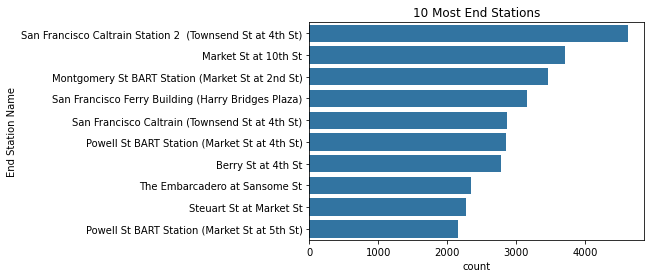

```python
#Check most start stations
sb.countplot(data = bike_df, y = 'end_station_name', order =bike_df.end_station_name.value_counts().index[0:10] , color = color_base)
plt.ylabel('End Station Name')
plt.title('10 Most End Stations');
```

```python
(bike_df.start_station_name.value_counts().index[:10]).isin(bike_df.end_station_name.value_counts().index[:10]).sum()
```

```
9
```

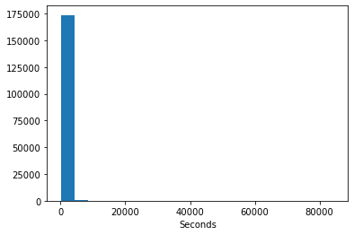

```python
#check the duration seconds distribution
plt.hist(data = bike_df, x = 'duration_sec', bins = 20)
plt.xlabel('Seconds');
```

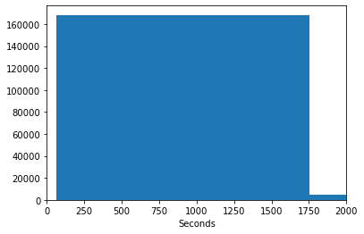

```python
#As the most of data exist at the start of x axis lets apply x limits on the x axis to exclude outlier if it exist
plt.hist(data = bike_df, x = 'duration_sec', bins = 50)
plt.xlabel('Seconds')
plt.xlim(0, 2000);
```

```python
#As the most of data still concentrated lets try to change the x scale
np.log10(bike_df['duration_sec']).describe()
```

```
count    174760.000000
mean          2.708088
std           0.304994
min           1.785330
25%           2.509203
50%           2.708421
75%           2.897077
max           4.927103
Name: duration_sec, dtype: float64
```

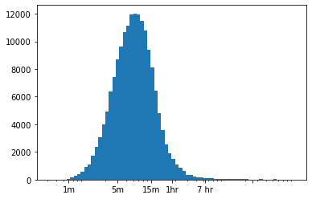

```python
#check the duration seconds distribution in log scale
bins = 10 ** np.arange(1.5, np.log10(bike_df['duration_sec'].max())+0.1, 0.05)
plt.hist(data = bike_df, x = 'duration_sec', bins = bins)
plt.xscale('log')
plt.xticks([60, 300, 900, 1800, 5400, 25200], ["1m", '5m', '15m',  '1hr', '7 hr']);
```

```python
bike_df2 = bike_df[bike_df.duration_sec > 2700]
bike_df = bike_df[bike_df.duration_sec <= 2700]
```

```python
bike_df2.shape
```

```
(2306, 19)
```

```python
bike[bike.member_birth_year < 1940].shape
```

```
(203, 16)
```

```python
bike[ (bike.duration_sec > 2700) & (bike.duration_sec < 67000) ].shape
```

```
(2718, 16)
```

```python
bike_df.describe()
```

|  | duration_sec | start_station_id | start_station_latitude | start_station_longitude | end_station_id | end_station_latitude | end_station_longitude | bike_id | member_birth_year | day_num | hour |
| --- | --- | --- | --- | --- | --- | --- | --- | --- | --- | --- | --- |
| count | 172454.000000 | 172454.000000 | 172454.000000 | 172454.000000 | 172454.000000 | 172454.000000 | 172454.000000 | 172454.000000 | 172454.000000 | 172454.000000 | 172454.000000 |
| mean | 605.483520 | 138.756091 | 37.771142 | -122.351531 | 136.179422 | 37.771332 | -122.351087 | 4479.706797 | 1984.884537 | 2.611009 | 13.452619 |
| std | 405.746427 | 111.318678 | 0.100589 | 0.117869 | 110.903838 | 0.100485 | 0.117415 | 1660.616277 | 9.858718 | 1.802367 | 4.742699 |
| min | 61.000000 | 3.000000 | 37.317298 | -122.453704 | 3.000000 | 37.317298 | -122.453704 | 11.000000 | 1939.000000 | 0.000000 | 0.000000 |
| 25% | 321.000000 | 47.000000 | 37.770407 | -122.411901 | 44.000000 | 37.770407 | -122.411647 | 3795.000000 | 1980.000000 | 1.000000 | 9.000000 |
| 50% | 505.000000 | 104.000000 | 37.780760 | -122.398279 | 101.000000 | 37.781010 | -122.397405 | 4959.000000 | 1987.000000 | 3.000000 | 14.000000 |
| 75% | 774.000000 | 239.000000 | 37.797320 | -122.283093 | 235.000000 | 37.797673 | -122.285633 | 5504.000000 | 1992.000000 | 4.000000 | 17.000000 |
| max | 2700.000000 | 398.000000 | 37.880222 | -121.874119 | 398.000000 | 37.880222 | -121.874119 | 6645.000000 | 2001.000000 | 6.000000 | 23.000000 |

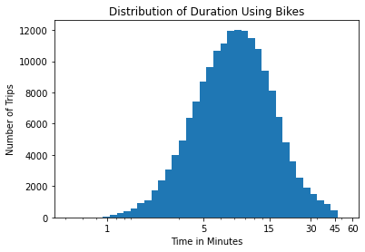

```python
bins = 10 ** np.arange(1.5, np.log10(bike_df['duration_sec'].max())+0.1, 0.05)
plt.hist(data = bike_df, x = 'duration_sec', bins = bins)
plt.xscale('log')
plt.xticks([60, 300, 900, 1800, 2700, 3600], ["1", '5', '15','30','45', '60' ])
plt.xlabel('Time in Minutes')
plt.ylabel('Number of Trips')
plt.title('Distribution of Duration Using Bikes');
```

```python
#bike_df[bike_df.member_gender == 'Male']['duration_sec'].resample('D').mean().plot(color = 'b', linestyle = '--')
#bike_df[bike_df.member_gender == 'Female']['duration_sec'].resample('D').mean().plot(color = 'r')
#bike_df['duration_sec'].resample('D').mean().plot(color = 'g')
#plt.legend(['Male','Female'])
```

### Discuss the distribution(s) of your variable(s) of interest. Were there any unusual points? Did you need to perform any transformations?

> Distributions of duration
> - The duration in seconds took on a large range of values, so I looked at the data using a log transform Under the transformation, the data looked unimodal, with one peak between 5 and 15 minutes

### Of the features you investigated, were there any unusual distributions? Did you perform any operations on the data to tidy, adjust, or change the form of the data? If so, why did you do this?

>

- The birth year of some subscribers not logical (birth year 1878 means that subscriber is 141 old), so we remove all subscribers above 80 old as we suspect that it's false data as bike is not safe for aging people.
- The main idea of bike share is using bike to move inside city fast from point to point not keeping bike with customer for long time or next day, so we slecte the max period of bike usage is 45 minutes and remove dataset whcih exceed that limit.

## Bivariate Exploration

> In this section, investigate relationships between pairs of variables in your data. Make sure the variables that you cover here have been introduced in some fashion in the previous section (univariate exploration).

```python
bike_df.head()
```

|  | duration_sec | start_time | end_time | start_station_id | start_station_name | start_station_latitude | start_station_longitude | end_station_id | end_station_name | end_station_latitude | end_station_longitude | bike_id | user_type | member_birth_year | member_gender | bike_share_for_all_trip | day | day_num | hour |
| --- | --- | --- | --- | --- | --- | --- | --- | --- | --- | --- | --- | --- | --- | --- | --- | --- | --- | --- | --- |
| 4 | 1585 | 2019-02-28 23:54:18.549 | 2019-03-01 00:20:44.074 | 7.0 | Frank H Ogawa Plaza | 37.804562 | -122.271738 | 222.0 | 10th Ave at E 15th St | 37.792714 | -122.248780 | 4898 | Subscriber | 1974.0 | Male | Yes | Thu | 3 | 23 |
| 5 | 1793 | 2019-02-28 23:49:58.632 | 2019-03-01 00:19:51.760 | 93.0 | 4th St at Mission Bay Blvd S | 37.770407 | -122.391198 | 323.0 | Broadway at Kearny | 37.798014 | -122.405950 | 5200 | Subscriber | 1959.0 | Male | No | Thu | 3 | 23 |
| 6 | 1147 | 2019-02-28 23:55:35.104 | 2019-03-01 00:14:42.588 | 300.0 | Palm St at Willow St | 37.317298 | -121.884995 | 312.0 | San Jose Diridon Station | 37.329732 | -121.901782 | 3803 | Subscriber | 1983.0 | Female | No | Thu | 3 | 23 |
| 7 | 1615 | 2019-02-28 23:41:06.766 | 2019-03-01 00:08:02.756 | 10.0 | Washington St at Kearny St | 37.795393 | -122.404770 | 127.0 | Valencia St at 21st St | 37.756708 | -122.421025 | 6329 | Subscriber | 1989.0 | Male | No | Thu | 3 | 23 |
| 8 | 1570 | 2019-02-28 23:41:48.790 | 2019-03-01 00:07:59.715 | 10.0 | Washington St at Kearny St | 37.795393 | -122.404770 | 127.0 | Valencia St at 21st St | 37.756708 | -122.421025 | 6548 | Subscriber | 1988.0 | Other | No | Thu | 3 | 23 |

```python
bike_df.describe()
```

|  | duration_sec | start_station_id | start_station_latitude | start_station_longitude | end_station_id | end_station_latitude | end_station_longitude | bike_id | member_birth_year | day_num | hour |
| --- | --- | --- | --- | --- | --- | --- | --- | --- | --- | --- | --- |
| count | 172454.000000 | 172454.000000 | 172454.000000 | 172454.000000 | 172454.000000 | 172454.000000 | 172454.000000 | 172454.000000 | 172454.000000 | 172454.000000 | 172454.000000 |
| mean | 605.483520 | 138.756091 | 37.771142 | -122.351531 | 136.179422 | 37.771332 | -122.351087 | 4479.706797 | 1984.884537 | 2.611009 | 13.452619 |
| std | 405.746427 | 111.318678 | 0.100589 | 0.117869 | 110.903838 | 0.100485 | 0.117415 | 1660.616277 | 9.858718 | 1.802367 | 4.742699 |
| min | 61.000000 | 3.000000 | 37.317298 | -122.453704 | 3.000000 | 37.317298 | -122.453704 | 11.000000 | 1939.000000 | 0.000000 | 0.000000 |
| 25% | 321.000000 | 47.000000 | 37.770407 | -122.411901 | 44.000000 | 37.770407 | -122.411647 | 3795.000000 | 1980.000000 | 1.000000 | 9.000000 |
| 50% | 505.000000 | 104.000000 | 37.780760 | -122.398279 | 101.000000 | 37.781010 | -122.397405 | 4959.000000 | 1987.000000 | 3.000000 | 14.000000 |
| 75% | 774.000000 | 239.000000 | 37.797320 | -122.283093 | 235.000000 | 37.797673 | -122.285633 | 5504.000000 | 1992.000000 | 4.000000 | 17.000000 |
| max | 2700.000000 | 398.000000 | 37.880222 | -121.874119 | 398.000000 | 37.880222 | -121.874119 | 6645.000000 | 2001.000000 | 6.000000 | 23.000000 |

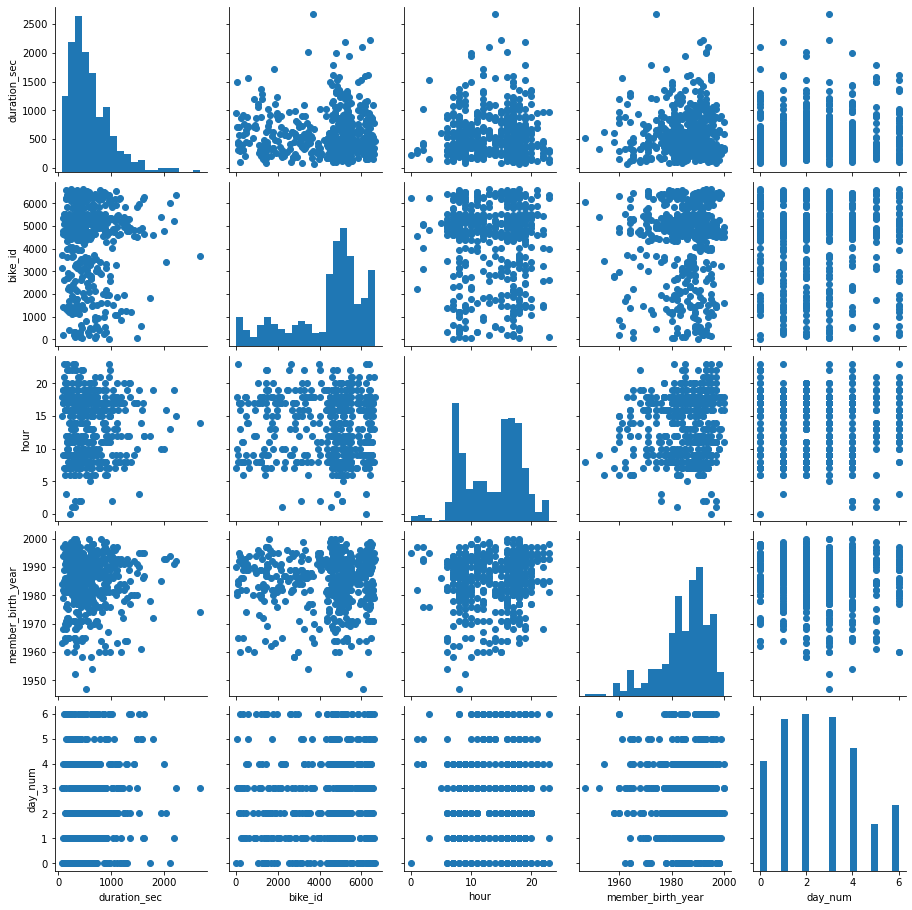

```python
# plot matrix: sample 500 diamonds so that plots are clearer and
# they render faster
numeric_vars = ['duration_sec','bike_id','hour','member_birth_year','day_num' ]
samples = np.random.choice(bike_df.shape[0], 500, replace = False)
bike_samp = bike_df.iloc[samples,:]

g = sb.PairGrid(data = bike_samp, vars = numeric_vars)
g = g.map_diag(plt.hist, bins = 20);
g.map_offdiag(plt.scatter);
```

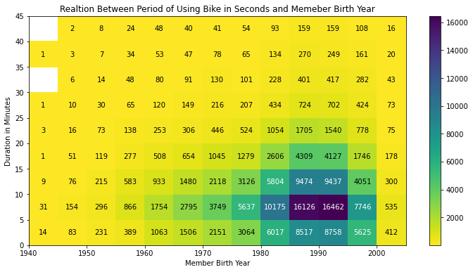

```python
# chech relation between member bithday and duration
plt.figure(figsize=[12,6])
bins_x = np.arange(1940, 2001+5, 5)
bins_y = np.arange(0, 2700+1, 300)

h2d = plt.hist2d(data = bike_df,x= 'member_birth_year', y = 'duration_sec' ,cmin =0.5, cmap ='viridis_r',bins = [bins_x, bins_y] )
counts = h2d[0]
for i in range(counts.shape[0]):
    for j in range(counts.shape[1]):
        c = counts[i,j]
        if c >= 5000: # increase visibility on darker cells
            plt.text(bins_x[i]+2.5, bins_y[j]+150, int(c),
                     ha = 'center', va = 'center', color = 'white')
        elif c > 0:
            plt.text(bins_x[i]+2.5, bins_y[j]+150, int(c),
                     ha = 'center', va = 'center', color = 'black')
plt.xlabel('Member Birth Year')
ticks= np.arange(0,2700+300,300)
labels= []
for i in ticks:
    labels.append(str(int(i/60)))
#plt.yticks([5,10,15,20,25,30,35,40,45], ['5','10','15','20','25','30','35','40', '45'])
plt.yticks(ticks,labels)
plt.ylabel('Duration in Minutes')
plt.title('Realtion Between Period of Using Bike in Seconds and Memeber Birth Year')
plt.colorbar();
```

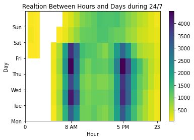

```python
#Check relation between day and hours for bike usage
#we select cmin = 61 as it the minimum time spent on a trip
bike_df['day_num'] = bike_df['start_time'].apply(lambda time: time.dayofweek)
bin_x=np.arange(0.5,23+1.5,1)
bin_y=np.arange(0,7+1,1)
plt.hist2d(data = bike_df,x= 'hour', y = 'day_num' ,cmin = 61, cmap ='viridis_r', bins=[bin_x, bin_y] );
plt.yticks([0,1,2,3,4,5,6],['Mon','Tue','Wed','Thu','Fri','Sat','Sun'])
plt.xticks([0,8,17,23], [0,'8 AM', '5 PM', 23])
plt.xlabel('Hour')
plt.ylabel('Day')
plt.title('Realtion Between Hours and Days during 24/7')
plt.colorbar();
```

```python
def tick_count_covert(x):
    '''Convert the Y ticks count of trips to be in thousands '''
    labels = []
    for i in x:
        labels.append(str(int(i/1000))+'K')
    return labels
```

```python
def tick_seconds_covert(x):
    '''Convert the Y ticks from seconds to be in minutes '''
    labels = []
    for i in x:
        labels.append(str(int(i/60)))
    return labels
```

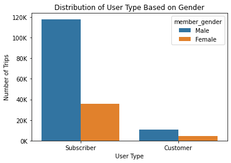

```python
sb.countplot(data = bike_df[bike_df.member_gender.isin(['Male','Female'])], x = 'user_type',  hue ='member_gender' );

ticks = np.arange(0,120000+20000, 20000)
labels = tick_count_covert(ticks)
plt.yticks(ticks,labels)
plt.xlabel('User Type')
plt.ylabel('Number of Trips')
plt.title('Distribution of User Type Based on Gender');
```

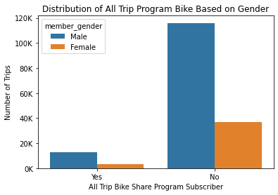

```python
sb.countplot(data = bike_df[bike_df.member_gender.isin(['Male','Female'])], x = 'bike_share_for_all_trip',  hue ='member_gender' )
ticks = np.arange(0,120000+20000, 20000)
labels = tick_count_covert(ticks)
plt.yticks(ticks,labels)
plt.xlabel('All Trip Bike Share Program Subscriber')
plt.ylabel('Number of Trips')
plt.title('Distribution of All Trip Program Bike Based on Gender');
```

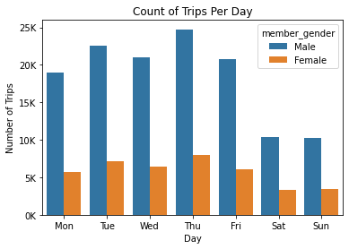

```python
#Check the countot trips per day
sb.countplot(data = bike_df[bike_df.member_gender.isin(['Male','Female'])], x = 'day',  hue ='member_gender')
ticks = np.arange(0,25000+5000, 5000)
labels = tick_count_covert(ticks)
plt.yticks(ticks, labels)
plt.ylabel('Number of Trips')
plt.xlabel('Day')
plt.title('Count of Trips Per Day');
```

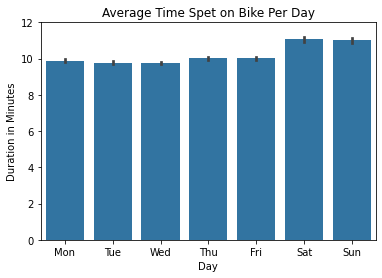

```python
#Check the average time spent using bikes per day
sb.barplot(data = bike_df[bike_df.member_gender.isin(['Male','Female'])], x = 'day',  y ='duration_sec', color= color_base )
ticks = np.arange(0,700+120, 120)
labels = tick_seconds_covert(ticks)
plt.yticks(ticks,labels)
plt.ylabel('Duration in Minutes')
plt.xlabel('Day')
plt.title('Average Time Spet on Bike Per Day');
```

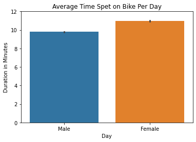

```python
#Check the average duration spent using bikes per gender
sb.barplot(data = bike_df[bike_df.member_gender.isin(['Male','Female'])], x = 'member_gender',  y ='duration_sec' );
ticks = np.arange(0,700+120, 120)
labels = tick_seconds_covert(ticks)
plt.yticks(ticks,labels)
plt.ylabel('Duration in Minutes')
plt.xlabel('Day')
plt.title('Average Time Spet on Bike Per Day');
```

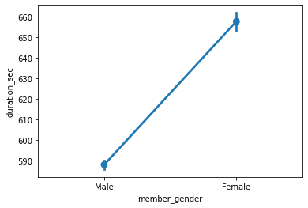

```python
#Check the average duration spent using bikes per gender
sb.pointplot(data = bike_df[bike_df.member_gender.isin(['Male','Female'])], x = 'member_gender',  y ='duration_sec' );
#This plot is bad visualization as the diferrence is 70 seconds only, the plot contain lie factor as Y axis not starting from zero
```

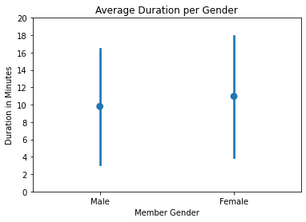

```python
#we have two ways to correct the plot
## adding sd factor in the plot
## adjust the y axis ticks to start from zero
sb.pointplot(data = bike_df[bike_df.member_gender.isin(['Male','Female'])], x = 'member_gender',
             y ='duration_sec', linestyles='' , ci='sd')
ticks = np.arange(0,1200+120, 120)
labels = tick_seconds_covert(ticks)
plt.yticks(ticks,labels)
plt.xlabel('Member Gender')
plt.ylabel('Duration in Minutes')
plt.title('Average Duration per Gender');
```

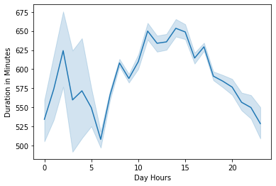

```python
#check averge duration using bike per hour
sb.lineplot(data= bike_df, x='hour', y = 'duration_sec', color = color_base)
#ticks = np.arange(500,720+60, 60)
#labels = tick_seconds_covert(ticks)
#plt.yticks(ticks,labels)
plt.ylabel('Duration in Minutes')
plt.xlabel('Day Hours');
```

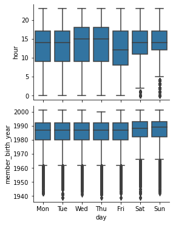

```python
#check  reation between weekdasy and (member_birth_year and hour)
def boxgrid(x, y, **kwargs):
    """ Quick hack for creating box plots with seaborn's PairGrid. """
    default_color = sb.color_palette()[0]
    sb.boxplot(x, y, color = default_color)


g = sb.PairGrid(data = bike_df, y_vars = ['hour', 'member_birth_year'], x_vars = 'day', aspect = 1.5);
g.map(boxgrid);
plt.show();
```

### Talk about some of the relationships you observed in this part of the investigation. How did the feature(s) of interest vary with other features in the dataset?

> Most people using the bike share system is between 20 and 40 years old and mostly using bike for less than 10 minutes trip, also it's clear the people depend on biks share system as transportation methoud to go to work and return back after working hours as in weekdays at **8 AM** and **5 PM** represnt the maximum trips counts

### Did you observe any interesting relationships between the other features (not the main feature(s) of interest)?

> We noticed interested observations
> - Although the number of trips on weekdays are more than weekends but on average the time spent using bikes on weekends are more
> - While Males are doing more trips than Females and also they are the most Subscriber on bike share system with **Large Difference** but on average Females are spending more time in using bikes with **Littel Difference**
> - 9 stations already exist in both most 10 Start and End stations
> - There is high varaince in trip duration after midnights

## Multivariate Exploration

> Create plots of three or more variables to investigate your data even further. Make sure that your investigations are justified, and follow from your work in the previous sections.

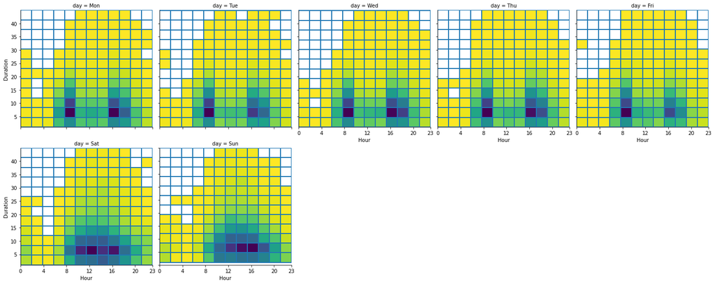

```python
#Bike using duration over the day hours per each day
g = sb.FacetGrid(data = bike_df, col = 'day', col_wrap = 5, size =4)

g.map(plt.hist2d, 'hour', 'duration_sec', cmin=5, cmap ='viridis_r', bins = 12,)
y_ticks = np.arange(0,2700+300, 300)
y_labels = tick_seconds_covert(y_ticks)
plt.yticks(y_ticks,y_labels)
x_ticks=np.arange(0.5,23+1.5,1)

plt.xticks([0,4,8,12,16,20,23], ['0','4','8','12','16', '20', '23'])
g.set_xlabels('Hour')
g.set_ylabels('Duration');
```

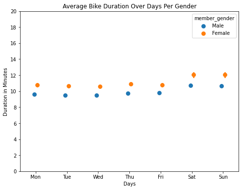

```python
#Check the avergar duration using bikes over days per gender
plt.figure(figsize=[8,6])
sb.pointplot(data = bike_df[bike_df.member_gender.isin(['Male','Female'])], x = 'day',  y ='duration_sec',
             hue='member_gender', dodge=0.1, linestyles='' );
ticks = np.arange(0,1200+120, 120)
labels = tick_seconds_covert(ticks)
plt.yticks(ticks,labels)
plt.xlabel('Days')
plt.ylabel('Duration in Minutes')
plt.title('Average Bike Duration Over Days Per Gender');
```

```python
#Spearte wkeekdays and weekends in dataframes
week_days= bike_df.loc[bike_df.day.isin(['Fri', 'Thu', 'Wed', 'Tue', 'Mon'])]
week_ends = bike_df.loc[bike_df.day.isin(['Sun', 'Sat'])]
```

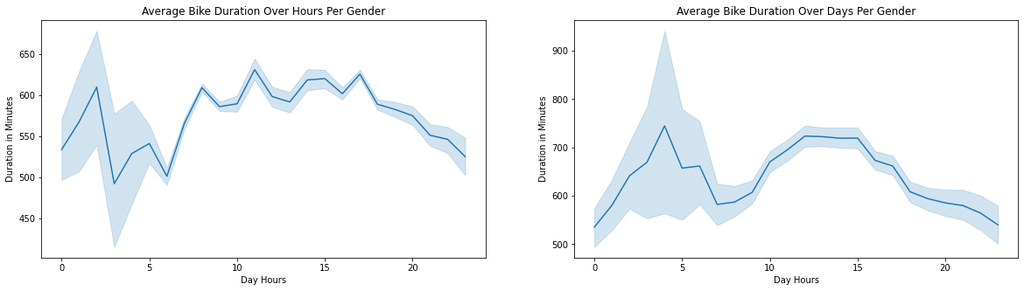

```python
#check averge duration using bike per hour
plt.figure(figsize = [20, 5])
plt.subplot(1,2,1)
sb.lineplot(data= week_days, x='hour', y = 'duration_sec', color = color_base)
#ticks = np.arange(500,720+60, 60)
#labels = tick_seconds_covert(ticks)
#plt.yticks(ticks,labels)
plt.ylabel('Duration in Minutes')
plt.xlabel('Day Hours')
plt.title('Average Bike Duration Over Hours Per Gender');

plt.subplot(1,2,2)
sb.lineplot(data= week_ends, x='hour', y = 'duration_sec', color = color_base)
#ticks = np.arange(500,720+60, 60)
#labels = tick_seconds_covert(ticks)
#plt.yticks(ticks,labels)
plt.ylabel('Duration in Minutes')
plt.xlabel('Day Hours')
plt.title('Average Bike Duration Over Days Per Gender');
```

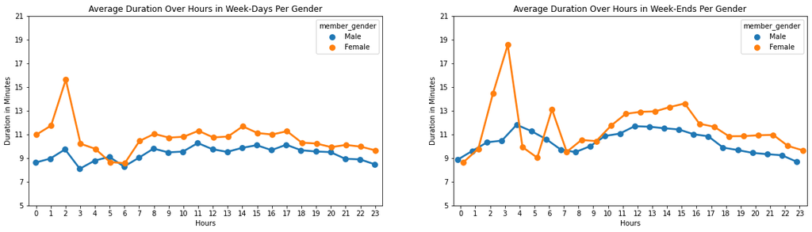

```python
plt.figure(figsize = [20, 5])
plt.subplot(1,2,1)
sb.pointplot(data = week_days[week_days.member_gender.isin(['Male','Female'])], x = 'hour',  y ='duration_sec',
             hue='member_gender', dodge=True, ci = None );
ticks = np.arange(300,1200+120, 120)
labels = tick_seconds_covert(ticks)
plt.yticks(ticks,labels)
plt.xlabel('Hours')
plt.ylabel('Duration in Minutes')
plt.title('Average Duration Over Hours in Week-Days Per Gender');
plt.subplot(1,2,2)
sb.pointplot(data = week_ends[week_ends.member_gender.isin(['Male','Female'])], x = 'hour',  y ='duration_sec',
             hue='member_gender', dodge=0.4 , ci = None);
ticks = np.arange(300,1200+120, 120)
labels = tick_seconds_covert(ticks)
plt.yticks(ticks,labels)
plt.xlabel('Hours')
plt.ylabel('Duration in Minutes')
plt.title('Average Duration Over Hours in Week-Ends Per Gender');
```

### Talk about some of the relationships you observed in this part of the investigation. Were there features that strengthened each other in terms of looking at your feature(s) of interest?

> We extended the investigation duration over the day hours per each day and find hwo it different between weekday and weekends. At weekday we noticed two peaks correlated with starting and ending business hours while at weekends people use bikes along the day hours from 10 AM to 6 PM.

### Were there any interesting or surprising interactions between features?

> At the end of your report, make sure that you export the notebook as an html file from the `File > Download as... > HTML` menu. Make sure you keep track of where the exported file goes, so you can put it in the same folder as this notebook for project submission. Also, make sure you remove all of the quote-formatted guide notes like this one before you finish your report!